# Homework 2

**Due Date:** 2022-10-16 at 8:30 AM PT

**Name:** Adam Seri-Levi

For this assignment, you will practice downloadings, cleaning, and analyzing data from the [National Risk Index (NRI)](https://hazards.fema.gov/nri/) and the [CDC Social Vulnerability Index (SVI)](https://www.atsdr.cdc.gov/placeandhealth/svi/index.html).

## Preparation

1. Create a ‘data’ folder in the root directory of your repository.
2. Inside the ‘data’ folder, create a ‘raw’ folder.
3. Add and commit a ‘.gitignore’ file to the root directory of this repository that excludes all contents of the ‘data’ folder.
4. Download the county-level NRI and SVI data for the entire United States. Place the data in the ‘data/raw’ folder.
5. In the repository README, provide a brief (1-2 sentence) description of each file in the ‘data’ folder and a link to the original source of the data.

## Task 1 - NRI Data Cleaning

**1. Import the NRI data. Ensure that the [FIPS code](https://en.wikipedia.org/wiki/Federal_Information_Processing_Standard_state_code) variable (‘STCOFIPS’) is correctly identified as a string / character variable. Otherwise, the leading zeros will be removed.**

```python
#importing packages
import pandas as pd
import matplotlib.pyplot as plt
import numpy as np

nri_data=r"C:\Users\aserilevi\code\PRGS-Intro-to-Machine-Learning\data\raw\National Risk Index (NRI) County Level Data\NRI_Table_Counties.csv"
nri_df=pd.read_csv(nri_data)
nri_df['STCOFIPS'] = nri_df['STCOFIPS'].astype(str)
stcofips_column = 'STCOFIPS'
```

**2. Subset the NRI data to include only the 5-digit state/county FIPS code and all colums ending with ‘_AFREQ’ and ‘_RISKR’. Each of these columns represents a different hazard type.**

```python
#Assigning the stcofips column to a variable
stcofips_column = 'STCOFIPS'

# Filter columns that end with '_AFREQ' or '_RISKR'
filtered_nri = nri_df.filter(regex='(_AFREQ|_RISKR)$').columns

# Include the STCOFIPS column
filtered_nri = [stcofips_column] + list(filtered_nri)

# Subset the DataFrame with only columns of interest
subset_nri = nri_df[filtered_nri]

# Restrict to rows where STCOFIPS has exactly 5 digits
subset_nri = subset_nri[subset_nri[stcofips_column].astype(str).str.match(r'^\d{5}$')]
```

**3. Create a table / dataframe that, for each hazard type, shows the number of missing values in the ‘_AFREQ’ and ‘_RISKR’ columns.**

```python
# Creating a function that counts missing values for each column in a dataFrame
def count_missing(df):
    return df.isna().sum()
# using the function to count missing in our subsetted dataframe
count_missing_subset_nri=count_missing(subset_nri)
# dropping the STCOFIPS column
count_missing_subset_nri = count_missing_subset_nri.drop('STCOFIPS')
# converting to dataframe
count_missing_subset_nri= pd.DataFrame(count_missing_subset_nri)
print(count_missing_subset_nri)
```

```
               0
AVLN_AFREQ  2789
AVLN_RISKR     0
CFLD_AFREQ  2386
CFLD_RISKR     0
CWAV_AFREQ     0
CWAV_RISKR     0
DRGT_AFREQ     7
DRGT_RISKR     0
ERQK_AFREQ     0
ERQK_RISKR     0
HAIL_AFREQ     7
HAIL_RISKR     0
HWAV_AFREQ     0
HWAV_RISKR     0
HRCN_AFREQ   765
HRCN_RISKR     0
ISTM_AFREQ   160
ISTM_RISKR     0
LNDS_AFREQ    10
LNDS_RISKR     0
LTNG_AFREQ    93
LTNG_RISKR     0
RFLD_AFREQ     0
RFLD_RISKR     0
SWND_AFREQ     7
SWND_RISKR     0
TRND_AFREQ     7
TRND_RISKR     0
TSUN_AFREQ  2829
TSUN_RISKR     0
VLCN_AFREQ  2843
VLCN_RISKR     0
WFIR_AFREQ    88
WFIR_RISKR     0
WNTW_AFREQ     0
WNTW_RISKR     0
```

**4. Show the cross-tabulation of the ‘AVLN_AFREQ’ and ‘AVLN_RISKR’ columns (including missing values). What do you observe?**

```python
#Creating a new column in the subset_nri dataframe that indicates where the value in AVLN_AFREQ is missing or observed
subset_nri['AVLN_AFREQ_MISSING'] = np.where(subset_nri['AVLN_AFREQ'].isna(),'Missing', 'Observed')

'''
##Checking that it worked
print(subset_nri[subset_nri['AVLN_AFREQ_MISSING'] == 'Observed'][['AVLN_AFREQ_MISSING', 'AVLN_AFREQ']])
'''
#cross tabulating, I noticed that there are no missing valuse except for wehn "AVLN_RISK" equals 'Not Applicable'. When it equals 'Not Applicable', "AVLN_RISK" is always missing, which makes sense since there is no risk associated when there isn't an applicable hazard

crosstab_df=pd.crosstab(
    subset_nri['AVLN_AFREQ_MISSING'],
    subset_nri['AVLN_RISKR'],
    dropna=False
)

print(crosstab_df)
```

```
AVLN_RISKR          Not Applicable  Relatively High  Relatively Low  \
AVLN_AFREQ_MISSING
Missing                       2789                0               0
Observed                         0                9              35

AVLN_RISKR          Relatively Moderate  Very High  Very Low
AVLN_AFREQ_MISSING
Missing                               0          0         0
Observed                             14          5        62
```

**5. Assuming that a risk that is “not applicable” to a county has an annualized frequency of 0, impute the relevant missing values in the ‘_AFREQ’ columns with 0.**

```python
#Identifying which columns ends with _AFREQ and _RISKR and assigning each to a variable
#I used chatgpt using the following prompt: "How to impute a value for multiple columns that follow a simialr naming structure based on the value in another column"
afreq_columns = [col for col in subset_nri.columns if col.endswith('_AFREQ')]
riskr_columns = [col for col in subset_nri.columns if col.endswith('_RISKR')]

#Impute zero in '_AFREQ' columns where the corresponding '_RISKR'columns are 'Not Applicable'
for riskr_columns, afreq_columns in zip(riskr_columns, afreq_columns):
    subset_nri.loc[subset_nri[riskr_columns] == 'Not Applicable', afreq_columns] = 0

'''
##Can check that this works by running the previous python cell and then running this one again, there should be ZERO counts of "Missing" in the cross tabulation for 'Not Applicable'
print(crosstab_df)
'''
```

```
'\n##Can check that this works by running the previous python cell and then running this one again, there should be ZERO counts of "Missing" in the cross tabulation for \'Not Applicable\'\nprint(crosstab_df)\n'
```

## Task 2 - SVI Data Cleaning

**1. Import the SVI data. Ensure that the FIPS code is correctly identified as a string / character variable. Otherwise, the leading zeros will be removed.** **1. Subset the SVI data to include only the following columns:** `ST, STATE, ST_ABBR, STCNTY, COUNTY, FIPS, LOCATION, AREA_SQMI, E_TOTPOP, EP_POV150, EP_UNEMP, EP_HBURD, EP_NOHSDP, EP_UNINSUR, EP_AGE65, EP_AGE17, EP_DISABL, EP_SNGPNT, EP_LIMENG, EP_MINRTY, EP_MUNIT, EP_MOBILE, EP_CROWD, EP_NOVEH, EP_GROUPQ, EP_NOINT, EP_AFAM, EP_HISP, EP_ASIAN, EP_AIAN, EP_NHPI, EP_TWOMORE, EP_OTHERRACE`

```python
svi_data= r"C:\Users\aserilevi\code\PRGS-Intro-to-Machine-Learning\data\raw\Social Vulnerability Index (SVI) County Level Data\SVI_2022_US_county.csv"
svi_df=pd.read_csv(svi_data)
svi_df['FIPS'] = svi_df['FIPS'].astype(str)

#identifying the columns I'm going to filter by
svi_columns = columns_to_select = [
    'ST', 'STATE', 'ST_ABBR', 'STCNTY', 'COUNTY', 'FIPS', 'LOCATION', 'AREA_SQMI',
    'E_TOTPOP', 'EP_POV150', 'EP_UNEMP', 'EP_HBURD', 'EP_NOHSDP', 'EP_UNINSUR', 'EP_AGE65',
    'EP_AGE17', 'EP_DISABL', 'EP_SNGPNT', 'EP_LIMENG', 'EP_MINRTY', 'EP_MUNIT', 'EP_MOBILE',
    'EP_CROWD', 'EP_NOVEH', 'EP_GROUPQ', 'EP_NOINT', 'EP_AFAM', 'EP_HISP', 'EP_ASIAN',
    'EP_AIAN', 'EP_NHPI', 'EP_TWOMORE', 'EP_OTHERRACE'
]

#filtering the columns in the svi table
filtered_svi=svi_df[svi_columns]
#print result
print(filtered_svi)
```

```
      ST    STATE ST_ABBR  STCNTY             COUNTY   FIPS  \
0      1  Alabama      AL    1001     Autauga County   1001
1      1  Alabama      AL    1003     Baldwin County   1003
2      1  Alabama      AL    1005     Barbour County   1005
3      1  Alabama      AL    1007        Bibb County   1007
4      1  Alabama      AL    1009      Blount County   1009
...   ..      ...     ...     ...                ...    ...
3139  56  Wyoming      WY   56037  Sweetwater County  56037
3140  56  Wyoming      WY   56039       Teton County  56039
3141  56  Wyoming      WY   56041       Uinta County  56041
3142  56  Wyoming      WY   56043    Washakie County  56043
3143  56  Wyoming      WY   56045      Weston County  56045

                        LOCATION     AREA_SQMI  E_TOTPOP  EP_POV150  ...  \
0        Autauga County, Alabama    594.454786     58761       20.2  ...
```

[output cut: 38 more lines]

**2. Create a table / dataframe that shows the number of missing values in each column. (Hint: if you wrote a function for Task 1, you can reuse it here.)**

```python
#using the function made in the previous task
svi_missing=count_missing(filtered_svi)
#turning it into a dataframe
svi_missing_df=pd.DataFrame(svi_missing)
#print result
print(svi_missing_df)
```

```
              0
ST            0
STATE         0
ST_ABBR       0
STCNTY        0
COUNTY        0
FIPS          0
LOCATION      0
AREA_SQMI     0
E_TOTPOP      0
EP_POV150     0
EP_UNEMP      0
EP_HBURD      0
EP_NOHSDP     0
EP_UNINSUR    0
EP_AGE65      0
EP_AGE17      0
EP_DISABL     0
EP_SNGPNT     0
EP_LIMENG     0
EP_MINRTY     0
EP_MUNIT      0
EP_MOBILE     0
EP_CROWD      0
EP_NOVEH      0
EP_GROUPQ     0
EP_NOINT      0
EP_AFAM       0
EP_HISP       0
EP_ASIAN      0
EP_AIAN       0
EP_NHPI       0
EP_TWOMORE    0
EP_OTHERRACE  0
```

## Task 3 - Data Merging

**1. Identify any FIPS codes that are present in the NRI data but not in the SVI data and vice versa. Describe any discrepancies and possible causes? What to these discrepancies, if any, mean for interpreting results based on the merged dataset moving forward?**

```python
#The NRI dataset has 3 FIPS columns, one for state, one for county, and one for a combination of both, called state county (STCO). The SVI data has one column named FIPS and another column named STCNTY (State County) which can be interpreted in the same way as the STCOFIPS column from the NRI data and we should keep this in mind moving forward as we can use this as a key to merge our datasets
```

[output not shown]

**2. Merge the NRI and SVI data on the FIPS code. Use an outer join to keep all counties in the final dataset.**

```python
##merging the subsetted and filtered dataframes on the FIPS and STCOFIPS keys
merged_nri_svi=pd.merge(subset_nri, filtered_svi, how='outer', left_on='STCOFIPS', right_on='FIPS')
#print result
print(merged_nri_svi)
```

```
     STCOFIPS  AVLN_AFREQ      AVLN_RISKR  CFLD_AFREQ           CFLD_RISKR  \
0       10001         0.0  Not Applicable    3.687000  Relatively Moderate
1       10003         0.0  Not Applicable    3.687000  Relatively Moderate
2       10005         0.0  Not Applicable    3.654749      Relatively High
3         NaN         NaN             NaN         NaN                  NaN
4         NaN         NaN             NaN         NaN                  NaN
...       ...         ...             ...         ...                  ...
3227      NaN         NaN             NaN         NaN                  NaN
3228      NaN         NaN             NaN         NaN                  NaN
3229      NaN         NaN             NaN         NaN                  NaN
3230      NaN         NaN             NaN         NaN                  NaN
3231      NaN         NaN             NaN         NaN                  NaN

      CWAV_AFREQ CWAV_RISKR  DRGT_AFREQ      DRGT_RISKR  ERQK_AFREQ  ...  \
0            0.0  No Rating    3.904782  Relatively Low    0.000330  ...
```

[output cut: 38 more lines]

**3. Create a table / dataframe that shows the number of missing values in each column of the merged dataset.**

```python
#using count_missing function to county how many missing values there are in merged dataframe
missing_merged=count_missing(merged_nri_svi)
missing_merged_df=pd.DataFrame(missing_merged)
#print result
print(missing_merged_df)
```

```
                0
STCOFIPS      318
AVLN_AFREQ    318
AVLN_RISKR    318
CFLD_AFREQ    318
CFLD_RISKR    318
...           ...
EP_ASIAN       88
EP_AIAN        88
EP_NHPI        88
EP_TWOMORE     88
EP_OTHERRACE   88

[71 rows x 1 columns]
```

## Task 4 - Data Analysis

**1. For each numerical variable in the merged dataset, plot a histogram showing the distribution of values. (Hint: write a function to make the histogram for a single variable, then use a loop or apply function to make the histograms for all numerical variables.)**

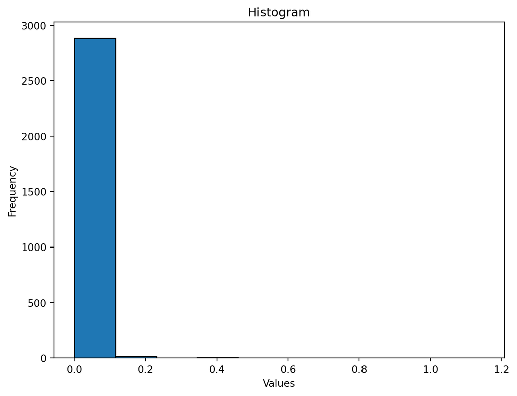

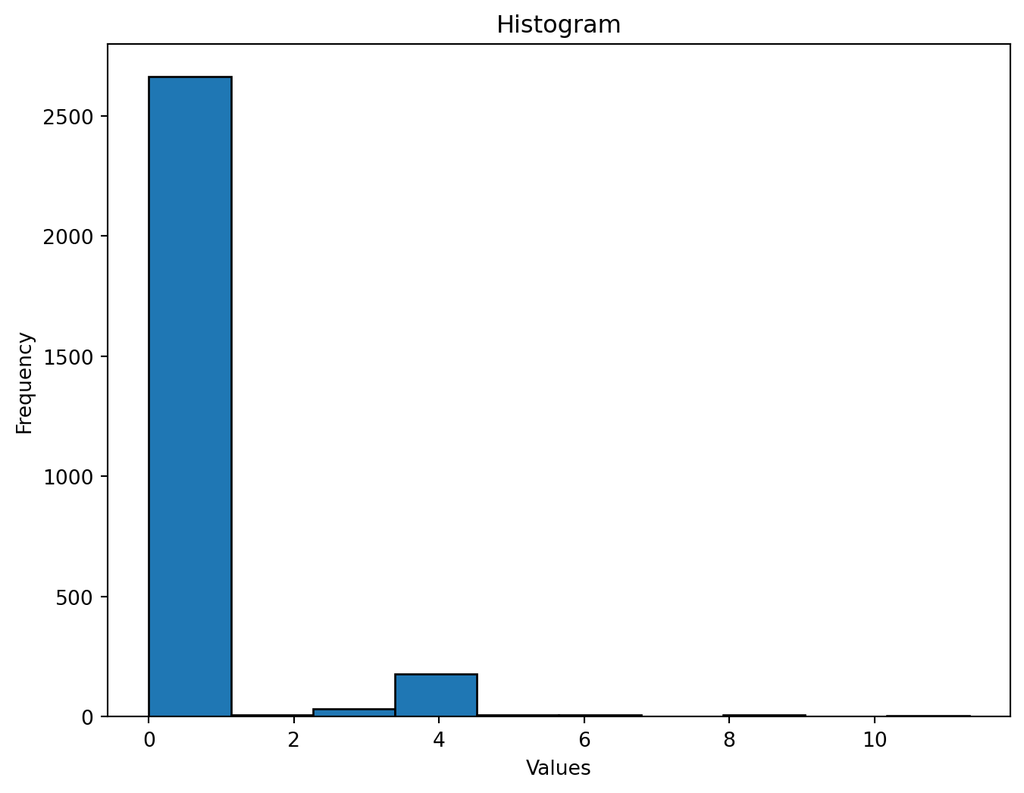

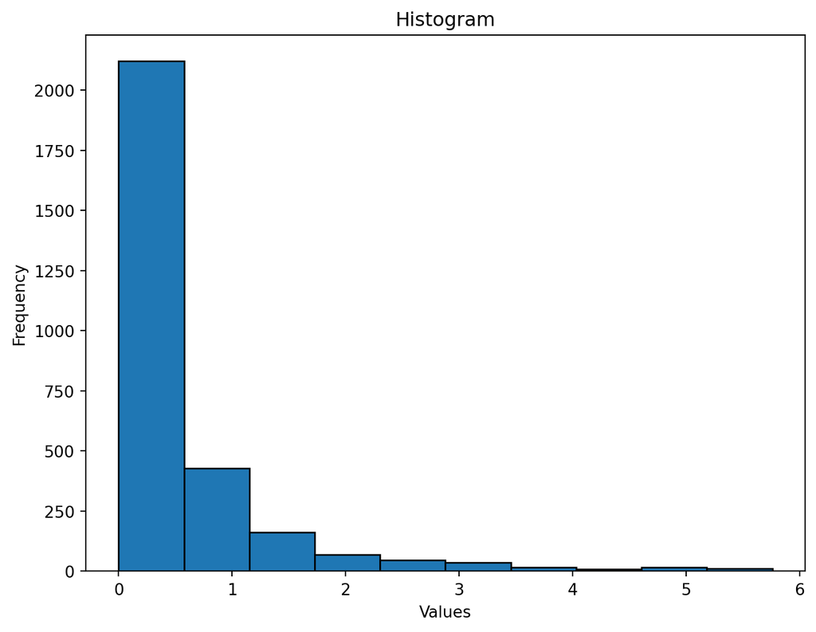

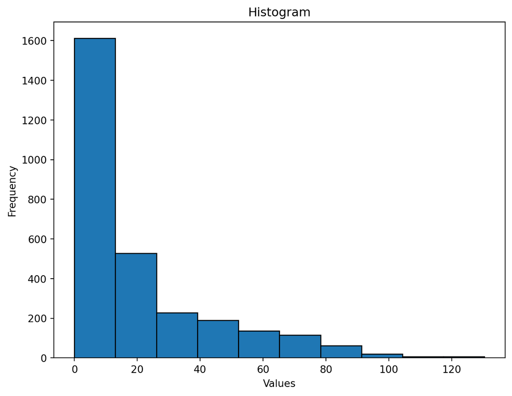

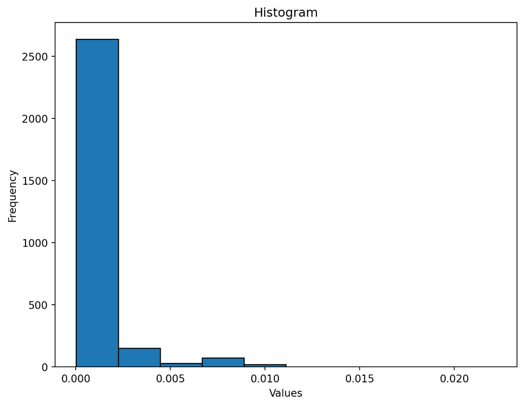

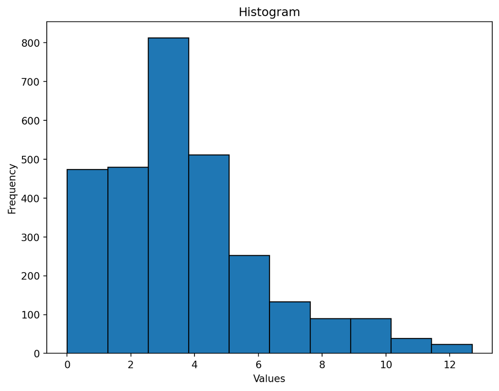

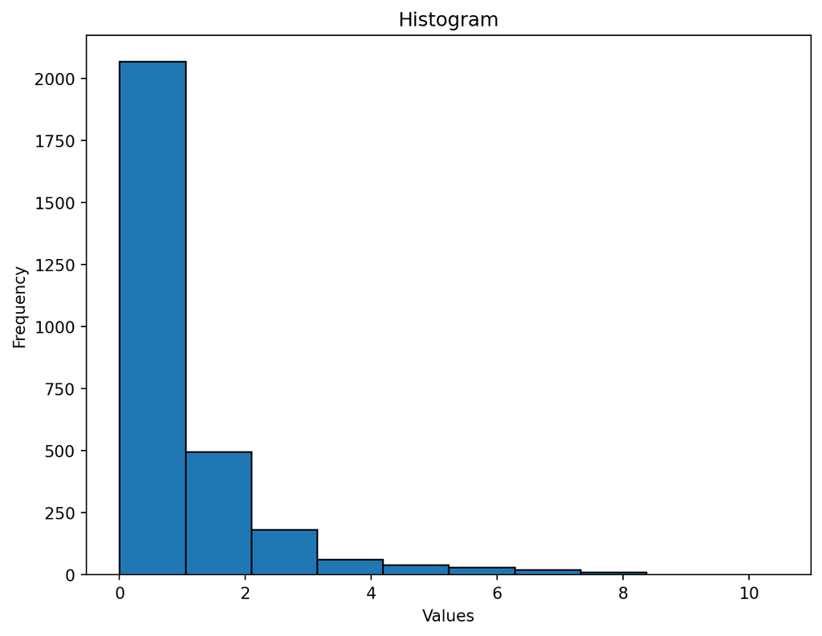

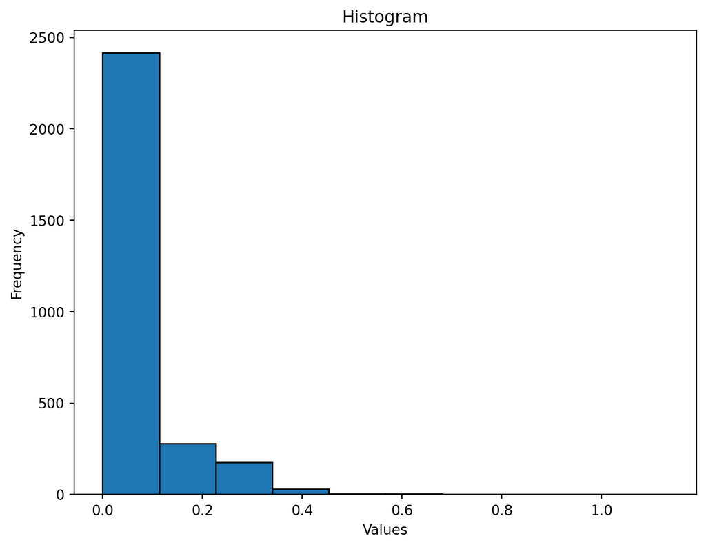

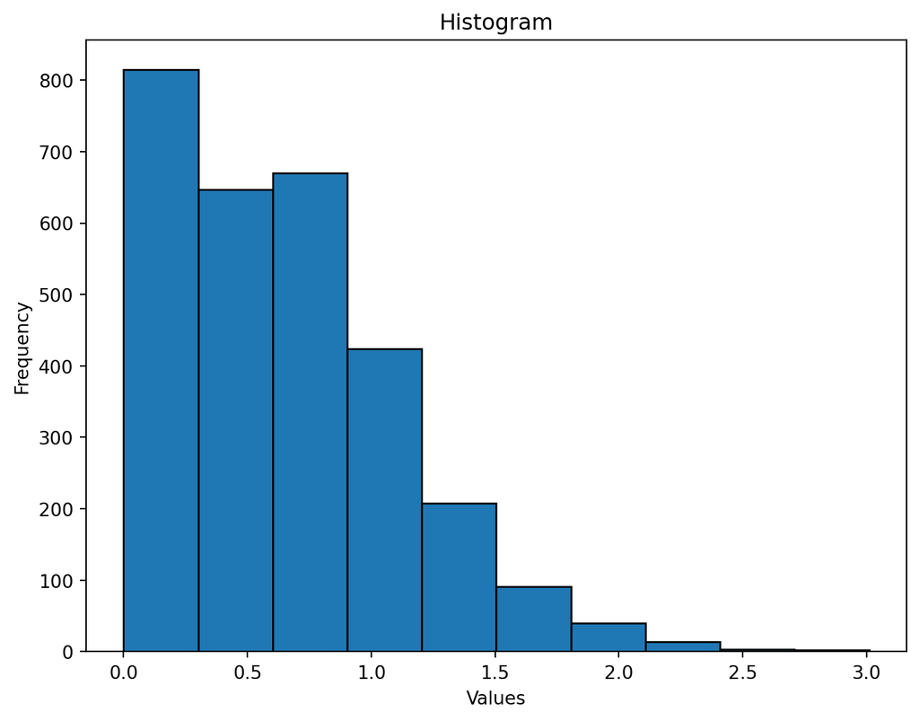

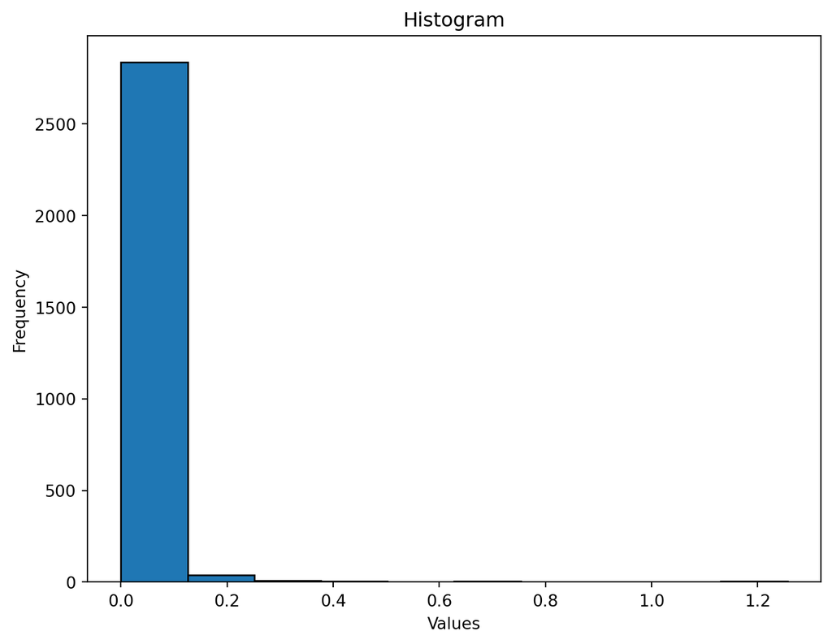

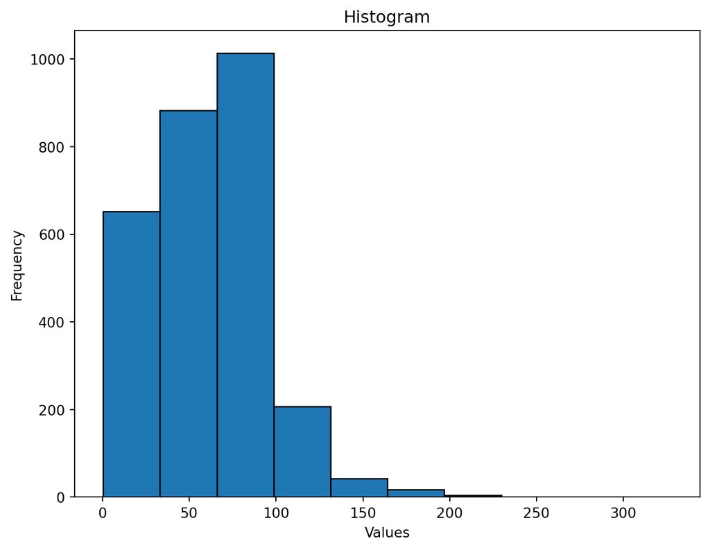

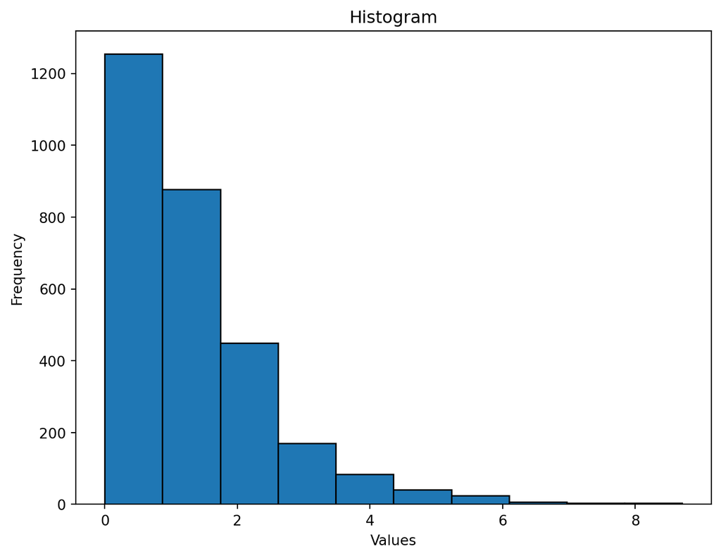

[34 more figures not shown]

```python
#I used chatgpt by asking it how to apply a function that creates a histogram for every numerical variable in a dataframe
def plot_histogram(data, bins=10, title='Histogram', xlabel='Values', ylabel='Frequency'):
    plt.figure(figsize=(8, 6))
    plt.hist(data, bins=bins, edgecolor='black')

    # Add title and axis labels
    plt.title(title)
    plt.xlabel(xlabel)
    plt.ylabel(ylabel)

    # Show the plot
    plt.show()
'''
#checking to see if it worked
hist_test= plot_histogram(merged_nri_svi['EP_MINRTY'])
'''
#assigning a variable that is only the numerical variables in the merged dataset
selecting_numerical_variables= merged_nri_svi.select_dtypes(include=['number'])
#applying the plot_Histogram function to all the numerical variables in the merged dataset
apply_hist=selecting_numerical_variables.apply(plot_histogram)
```